# Set up Jupyter Notebooks and Python

The main programming language of this tutorial is Python, a highly popular language in data and analytics, machine learning and many other fields. I asked ChatGPT "Why is Python a popular programming language?", and this was its response:

> Python is a popular programming language for several reasons:
> - **Readability and Simplicity**: Python's syntax is clear and easy to read, which makes it an excellent language for beginners. Its indentation-based formatting enforces code readability and reduces the chances of syntactical errors.
> - **Versatility**: Python is a versatile language that can be used for a wide range of applications, from web development and data analysis to artificial intelligence and scientific computing. It has a vast ecosystem of libraries and frameworks that make it suitable for various tasks.
> - **Large and Active Community**: Python has a large and active community of developers who contribute to its growth and provide support through forums, online communities, and open-source projects. This makes it easier for developers to find solutions to problems and stay updated with the latest trends.
> - **Cross-Platform Compatibility**: Python is available on multiple platforms, including Windows, macOS, and Linux, making it accessible to a broad audience. It's also compatible with various hardware architectures.
> - **Libraries and Frameworks**: Python has a rich ecosystem of libraries and frameworks that simplify complex tasks. For example, libraries like NumPy, pandas, and Matplotlib are popular for data analysis and visualization, while Django and Flask are popular for web development.
> - **Scalability**: Python can be used for both small scripts and large-scale applications. Its scalability is demonstrated by its use in building complex systems and applications, such as Instagram, YouTube, and Dropbox.
> - **Open Source**: Python is open source, meaning that it's free to use and can be customized according to specific needs. This encourages innovation and adoption in various industries.
> - **Support for Multiple Programming Paradigms**: Python supports multiple programming paradigms, including object-oriented, functional, and procedural programming. This flexibility allows developers to choose the approach that best suits their problem-solving needs.
> - **Education and Learning**: Python is often recommended as a first programming language for beginners and is widely used in educational settings. Its gentle learning curve and abundance of learning resources make it an accessible choice for those new to programming.
> - **Integration Capabilities**: Python can easily integrate with other languages like C, C++, and Java. This allows developers to leverage existing codebases and libraries written in other languages.
> - **Community-Driven Updates**: The Python community actively works on improving the language with regular releases. This ensures that Python remains up-to-date with the latest technologies and best practices.

And while I was at it, I also asked why Jupyter notebooks are a good choice of editor for a PC tutorial in Python. Here are some of the reasons it listed:

> - **Interactive Environment**: Jupyter Notebooks provide an interactive environment where code can be executed in cells, allowing learners to see immediate results. This interactivity makes it ideal for step-by-step tutorials and demonstrations.
> - **Mix of Code and Markdown**: Notebooks allow you to seamlessly mix code cells with markdown cells, enabling you to provide explanations, instructions, and comments alongside the code. This makes tutorials more accessible and easier to follow.
> - **Rich Text Formatting**: You can use Markdown cells to include formatted text, images, hyperlinks, and LaTeX equations. This allows you to create well-structured and visually appealing tutorials that explain concepts effectively.
> - **Easy Code Exploration**: Learners can modify and run code cells to experiment with different inputs or variations of code examples. This hands-on experience fosters a deeper understanding of Python and the concepts being taught.
> - **Error Handling and Debugging*: When learners encounter errors, they can see the error messages and traceback right in the notebook. This encourages troubleshooting and learning from mistakes, an essential aspect of programming.
> - **Data Visualization**: Notebooks support inline data visualization libraries like Matplotlib, Seaborn, and Plotly. This is particularly useful when teaching data science or data analysis, as learners can visualize data directly in the tutorial.
> - **Code Reusability**: You can define functions and classes in one cell and use them throughout the notebook. This promotes code modularity and reusability, encouraging best practices in software development.
> - **Integration with External Libraries**: Jupyter Notebooks can be integrated with various external libraries and tools, such as pandas, scikit-learn, TensorFlow, and more. This allows you to create comprehensive tutorials that cover a wide range of Python and data science topics.
> - **Community Support**: Jupyter Notebooks have a thriving community, which means that there are plenty of resources, extensions, and templates available to help you create engaging and effective tutorials.
> - **Platform Agnostic**: Jupyter Notebooks are platform-agnostic and run in web browsers, making them accessible to learners using different operating systems.
> - **Export Options**: Notebooks can be exported to various formats, including HTML, PDF, and slides. This flexibility allows you to distribute tutorials in different ways to cater to your audience's preferences.

> In summary, Jupyter Notebooks are a powerful tool for creating Python tutorials because they provide an interactive, integrated, and versatile environment that supports both code execution and rich documentation. This combination makes them well-suited for educational content that aims to teach Python programming and related topics effectively.

Most of these reasons are directly applicable to our purposes in this tutorial. Another reason for Python, which was not listed by ChatGPT, is that it is a valuable resource on the job market due to its popularity in the industry. However, if you are already familiar with any other programming language, you can of course try to replicate the tutorials in any other environment too. For that case, I have exported all the notebooks as .html files (your browser will open them), so you can read the content of the tutorials without installing anything.

### Installation

If you want to go ahead and try out Python in Jupyter Notebooks, you first need to install Anaconda. You can get it for free on https://www.anaconda.org/download. Choose the correct operating system and proceed as you would for any other installation. If you use Jupyter, you won't have to do anything else. It comes with a Python distribution, and all the external packages you need. If you want to use any other editor (Visual Studio Code is a popular choice as well), you will have to download Python separately and also install the external packages (in this tutorial: numpy and matplotlib) by yourself too.

### Open a notebook

You will notice that it won't be possible to open the notebooks (.ipynb files) by simply double-clicking them as you would with any other file. Instead, you will have to open Jupyter first and access them through your browser. My preferred way to do this is to open Jupyter directly in the folder I want to work in. There are a few steps to do this:

- open the folder you want to work in and copy the address
- open the Anaconda powershell
- type: "cd [folder address]" (cd changes the directory in the powershell) and press enter
- type: "jupyter notebook"

Once all this is completed, a new tab in your browser should open. It shows you the directory you are working in and all of its contents. Note that even though you are working in the browser, you do not need access to the internet. To open any notebook now, simply click it. On the right hand side, you will see a `New` button, which expands and lets you create a new Python notebook.

Below you can find a few screenshots to illustrate the steps:

- change directory:

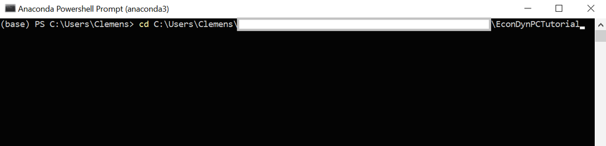

- open a notebook from the new directory

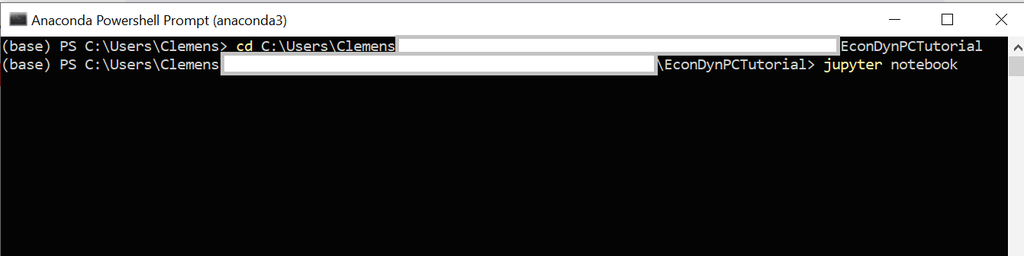

- Jupyter home

[figure not shown]

This should be about as much as you need to complete these tutorials. The explanations of the methods are in the tutorials, and the parts of the code that you are required to complete are clearly indicated as well. A few more useful features might be worth explaning though.

### A few notes on the use of notebooks

Once you open the notebooks, you will see that they are organised in "cells". These cells can contain code or text, in the so-called markdown formatting. At the top of the notebook you can find a dropdown menu with which you can change the type of the cell that is currently highlighted. Code cells can be recognised as on their left hand side it says `In [ ]:`, for input. They define the code input. The square brackets are empty if the cell has not been run yet, and they contain a number if it has. The numbers indicate the order in which cells have been run: they next time you run a cell, the number is incremented by one, relative to the last cell you have run. As you are not required to run cells in the order they appear in the notebook, this can be helpful to keep track of things. Once you have run a code cell, it may show and output underneath, if the last line of code in the cell produced one. If you want to print out a the output of a line further up in the cell, you can use Python's `print()` function.

Run the cell below to see how it creates an output:

```python
4+5
```

```
9
```

The following cell does not produce any output, as the statement `x = 4 + 5` only stores an object (the result of $4+5$) in the computer's memory and assigns the variable `x` to it:

```python
x = 4+5
```

And an expression that is not in the last line wouldn't produce a visible output either:

```python
4 + 4
x = 4 + 4
```

But you can use the `print()` function to have the output printed out. Note how this is not classified as an output (no `Out [n]:` next to it), because you are printing something to the console

```python
print(4+4)
x = 4+4
```

```
8
```

Markdown cells allow for detailed explanations in between code. By wrapping code in dollar signs , you can furthermore use LaTeX typesetting and fonts. E.g. `$\int_0^{\infty}e^{-x} dx$` yields $\int_0^{\infty}e^{-x} dx$. This is especially useful to type mathematical expressions. If you double-click a textfield in the notebooks, it will open up the markdown formatting cell, and you can check what I did to produce e.g. bullet points, italics and bold font, or other formatting tricks.